# Clustering and classification

*This week I have covered clustering and classification and data wrangling for next week exercise.*

```r
date()
```

```
## [1] "Sat Nov 27 18:20:28 2021"
```

### 2. Information of Boston dataset from the MASS package

```r
# access the MASS package
library(MASS)

# load the data
data("Boston")

# explore the dataset
str(Boston)
```

```
## 'data.frame':    506 obs. of  14 variables:
##  $ crim   : num  0.00632 0.02731 0.02729 0.03237 0.06905 ...
##  $ zn     : num  18 0 0 0 0 0 12.5 12.5 12.5 12.5 ...
##  $ indus  : num  2.31 7.07 7.07 2.18 2.18 2.18 7.87 7.87 7.87 7.87 ...
##  $ chas   : int  0 0 0 0 0 0 0 0 0 0 ...
##  $ nox    : num  0.538 0.469 0.469 0.458 0.458 0.458 0.524 0.524 0.524 0.524 ...
##  $ rm     : num  6.58 6.42 7.18 7 7.15 ...
##  $ age    : num  65.2 78.9 61.1 45.8 54.2 58.7 66.6 96.1 100 85.9 ...
##  $ dis    : num  4.09 4.97 4.97 6.06 6.06 ...
##  $ rad    : int  1 2 2 3 3 3 5 5 5 5 ...
##  $ tax    : num  296 242 242 222 222 222 311 311 311 311 ...
##  $ ptratio: num  15.3 17.8 17.8 18.7 18.7 18.7 15.2 15.2 15.2 15.2 ...
##  $ black  : num  397 397 393 395 397 ...
##  $ lstat  : num  4.98 9.14 4.03 2.94 5.33 ...
##  $ medv   : num  24 21.6 34.7 33.4 36.2 28.7 22.9 27.1 16.5 18.9 ...
```

```r
summary(Boston)
```

```
##       crim                zn             indus            chas
##  Min.   : 0.00632   Min.   :  0.00   Min.   : 0.46   Min.   :0.00000
##  1st Qu.: 0.08205   1st Qu.:  0.00   1st Qu.: 5.19   1st Qu.:0.00000
##  Median : 0.25651   Median :  0.00   Median : 9.69   Median :0.00000
##  Mean   : 3.61352   Mean   : 11.36   Mean   :11.14   Mean   :0.06917
##  3rd Qu.: 3.67708   3rd Qu.: 12.50   3rd Qu.:18.10   3rd Qu.:0.00000
##  Max.   :88.97620   Max.   :100.00   Max.   :27.74   Max.   :1.00000
##       nox               rm             age              dis
##  Min.   :0.3850   Min.   :3.561   Min.   :  2.90   Min.   : 1.130
##  1st Qu.:0.4490   1st Qu.:5.886   1st Qu.: 45.02   1st Qu.: 2.100
##  Median :0.5380   Median :6.208   Median : 77.50   Median : 3.207
##  Mean   :0.5547   Mean   :6.285   Mean   : 68.57   Mean   : 3.795
##  3rd Qu.:0.6240   3rd Qu.:6.623   3rd Qu.: 94.08   3rd Qu.: 5.188
##  Max.   :0.8710   Max.   :8.780   Max.   :100.00   Max.   :12.127
##       rad              tax           ptratio          black
##  Min.   : 1.000   Min.   :187.0   Min.   :12.60   Min.   :  0.32
##  1st Qu.: 4.000   1st Qu.:279.0   1st Qu.:17.40   1st Qu.:375.38
##  Median : 5.000   Median :330.0   Median :19.05   Median :391.44
##  Mean   : 9.549   Mean   :408.2   Mean   :18.46   Mean   :356.67
##  3rd Qu.:24.000   3rd Qu.:666.0   3rd Qu.:20.20   3rd Qu.:396.23
##  Max.   :24.000   Max.   :711.0   Max.   :22.00   Max.   :396.90
##      lstat            medv
##  Min.   : 1.73   Min.   : 5.00
##  1st Qu.: 6.95   1st Qu.:17.02
##  Median :11.36   Median :21.20
##  Mean   :12.65   Mean   :22.53
##  3rd Qu.:16.95   3rd Qu.:25.00
##  Max.   :37.97   Max.   :50.00
```

This dataset contains information of 506 houses in Boston suburbs. This dataset has 14 columns. The data attributes include features such as per capita crime rate by town, proportion of residential land zoned for lots over 25,000 sq.ft., social and Charles River dummy variable (= 1 if tract bounds river; 0 otherwise)) and so on. You may see the all the features explained in brief.

crim :per capita crime rate by town. zn : proportion of residential land zoned for lots over 25,000 sq.ft. indus : proportion of non-retail business acres per town. chas :Charles River dummy variable (= 1 if tract bounds river; 0 otherwise). nox : nitrogen oxides concentration (parts per 10 million). rm :average number of rooms per dwelling. age :proportion of owner-occupied units built prior to 1940. dis :weighted mean of distances to five Boston employment centres. rad :index of accessibility to radial highways. tax :full-value property-tax rate per $10,000. ptratio : pupil-teacher ratio by town. black :1000(Bk - 0.63)^2 where Bk is the proportion of blacks by town. lstat : lower status of the population (percent). medv : median value of owner-occupied homes in $1000s.

### 3.1 Graphical overview of the data and show summaries of the variables in the data

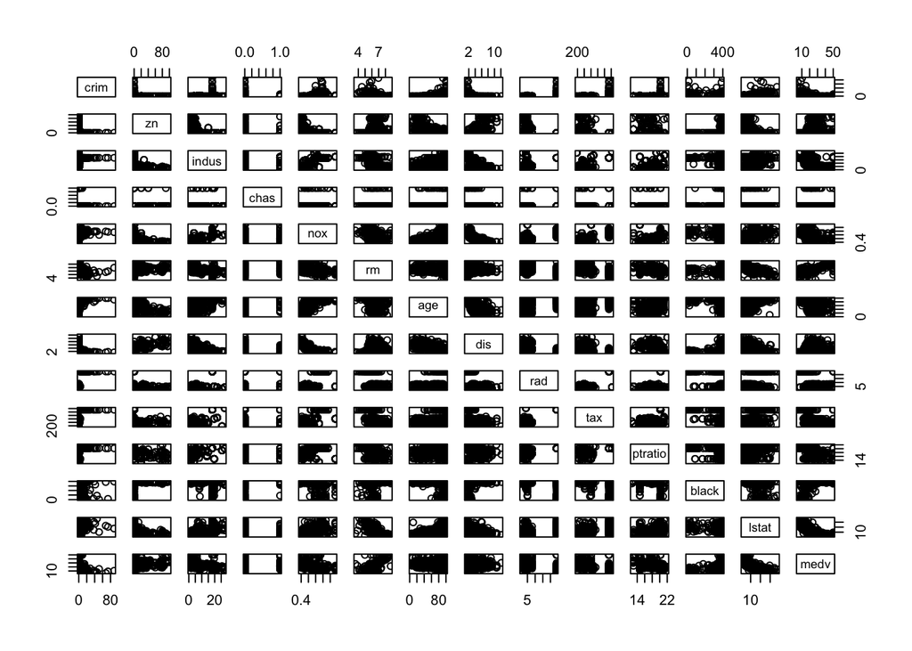

```r
# MASS, corrplot, tidyr and Boston dataset are available
library(tidyr)
library(corrplot)
# plot matrix of the variables
pairs(Boston)
```

```r
# calculate the correlation matrix and round it
cor_matrix<-cor(Boston) %>% round(digits = 2)

# print the correlation matrix
cor_matrix
```

```
##          crim    zn indus  chas   nox    rm   age   dis   rad   tax ptratio
## crim     1.00 -0.20  0.41 -0.06  0.42 -0.22  0.35 -0.38  0.63  0.58    0.29
## zn      -0.20  1.00 -0.53 -0.04 -0.52  0.31 -0.57  0.66 -0.31 -0.31   -0.39
## indus    0.41 -0.53  1.00  0.06  0.76 -0.39  0.64 -0.71  0.60  0.72    0.38
## chas    -0.06 -0.04  0.06  1.00  0.09  0.09  0.09 -0.10 -0.01 -0.04   -0.12
## nox      0.42 -0.52  0.76  0.09  1.00 -0.30  0.73 -0.77  0.61  0.67    0.19
## rm      -0.22  0.31 -0.39  0.09 -0.30  1.00 -0.24  0.21 -0.21 -0.29   -0.36
## age      0.35 -0.57  0.64  0.09  0.73 -0.24  1.00 -0.75  0.46  0.51    0.26
## dis     -0.38  0.66 -0.71 -0.10 -0.77  0.21 -0.75  1.00 -0.49 -0.53   -0.23
## rad      0.63 -0.31  0.60 -0.01  0.61 -0.21  0.46 -0.49  1.00  0.91    0.46
## tax      0.58 -0.31  0.72 -0.04  0.67 -0.29  0.51 -0.53  0.91  1.00    0.46
## ptratio  0.29 -0.39  0.38 -0.12  0.19 -0.36  0.26 -0.23  0.46  0.46    1.00
## black   -0.39  0.18 -0.36  0.05 -0.38  0.13 -0.27  0.29 -0.44 -0.44   -0.18
## lstat    0.46 -0.41  0.60 -0.05  0.59 -0.61  0.60 -0.50  0.49  0.54    0.37
## medv    -0.39  0.36 -0.48  0.18 -0.43  0.70 -0.38  0.25 -0.38 -0.47   -0.51
##         black lstat  medv
## crim    -0.39  0.46 -0.39
## zn       0.18 -0.41  0.36
## indus   -0.36  0.60 -0.48
## chas     0.05 -0.05  0.18
## nox     -0.38  0.59 -0.43
## rm       0.13 -0.61  0.70
## age     -0.27  0.60 -0.38
## dis      0.29 -0.50  0.25
## rad     -0.44  0.49 -0.38
## tax     -0.44  0.54 -0.47
## ptratio -0.18  0.37 -0.51
## black    1.00 -0.37  0.33
## lstat   -0.37  1.00 -0.74
## medv     0.33 -0.74  1.00
```

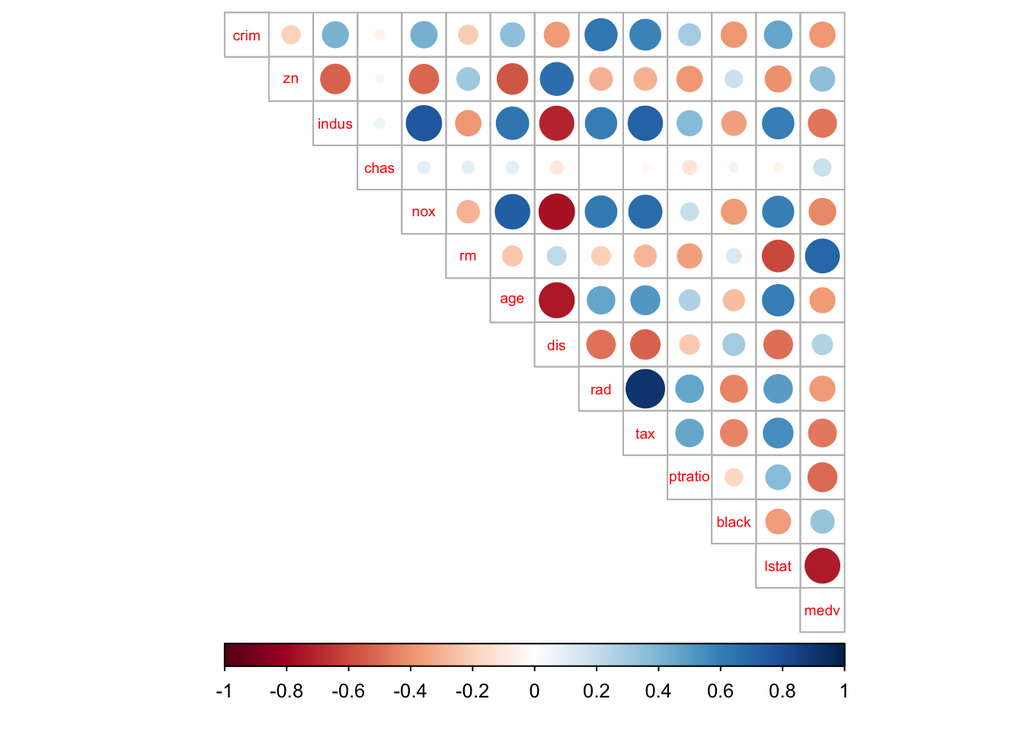

```r
# visualize the correlation matrix
corrplot(cor_matrix, method="circle", type="upper", cl.pos="b", tl.pos="d", tl.cex = 0.6)



# access the GGally and ggplot2 libraries
library(GGally)
```

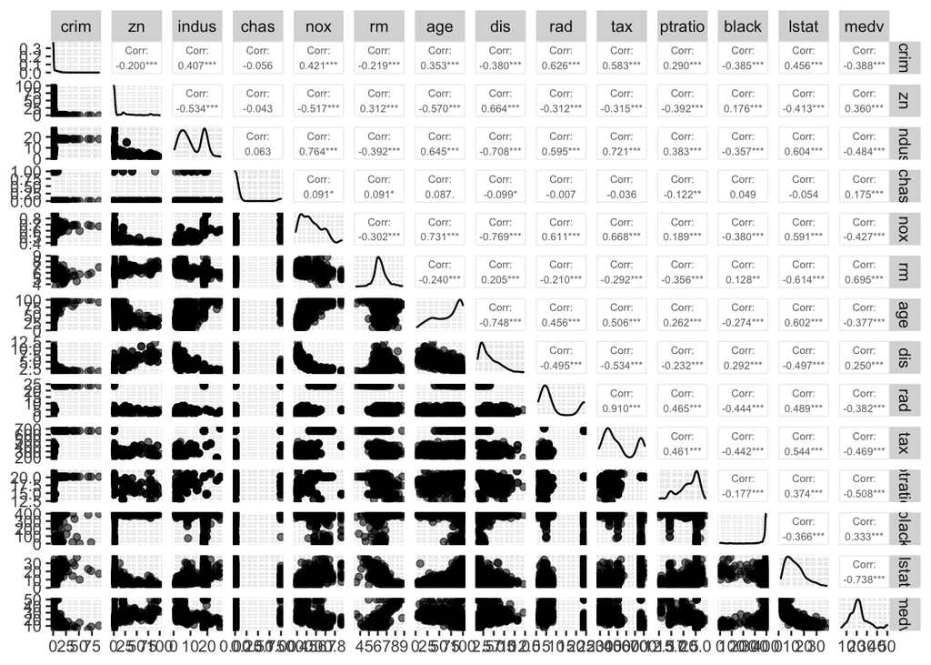

```r
library(ggplot2)
library(dplyr)
# create a more advanced plot matrix with ggpairs() : draws all possible scatter plots from the columns of a data frame, resulting in a scatter plot matrix.
p <- ggpairs(Boston, mapping = aes( alpha = 0.3), lower = list(combo = wrap("facethist", bins = 20)),upper = list(continuous = wrap("cor", size = 2)))
# draw the plot
p
```

### 3.2 Interpretation of results

We can Immediately notice that,

- **dis** has a strong negative correlation with **indus**. This is due to the fact that when proportion of non-retail business acres per town increases weighted mean of distances to five Boston employment centres decreases.
- We do not see a strong correlation between **chas** variable and **rad**. That is because index of accessibility to radial highways does not depend on Charles River dummy variable. These two variables can be considered as almost independent.
- **nox** has a strong positive correlation to **indus**. It is obvious that nitrogen oxides concentration increases when proportion of non-retail business acres per town increases.
- **rad** has a strong correlation to **indus**, **nox**, **crim** and **age**. That is due to the fact that index of accessibility to radial highways has a positive relationship with proportion of non-retail business acres per town, nitrogen oxides concentration, per capita crime rate by town and proportion of owner-occupied units built prior to 1940.
- **rn** has a positive correlation with **zn**. That is because average number of rooms per dwelling increases with the proportion of residential land zoned for lots over 25,000 sq.ft.

### 4.1 Standardization

- In the Standardization, we subtract the column means from the corresponding columns and divide the difference with standard deviation.
- The Boston data contains only numerical values, so we can use the function scale() to standardize the whole dataset.

```r
# center and standardize variables
boston_scaled <- scale(Boston)

# summaries of the scaled variables
summary(boston_scaled)
```

```
##       crim                 zn               indus              chas
##  Min.   :-0.419367   Min.   :-0.48724   Min.   :-1.5563   Min.   :-0.2723
##  1st Qu.:-0.410563   1st Qu.:-0.48724   1st Qu.:-0.8668   1st Qu.:-0.2723
##  Median :-0.390280   Median :-0.48724   Median :-0.2109   Median :-0.2723
##  Mean   : 0.000000   Mean   : 0.00000   Mean   : 0.0000   Mean   : 0.0000
##  3rd Qu.: 0.007389   3rd Qu.: 0.04872   3rd Qu.: 1.0150   3rd Qu.:-0.2723
##  Max.   : 9.924110   Max.   : 3.80047   Max.   : 2.4202   Max.   : 3.6648
##       nox                rm               age               dis
##  Min.   :-1.4644   Min.   :-3.8764   Min.   :-2.3331   Min.   :-1.2658
##  1st Qu.:-0.9121   1st Qu.:-0.5681   1st Qu.:-0.8366   1st Qu.:-0.8049
##  Median :-0.1441   Median :-0.1084   Median : 0.3171   Median :-0.2790
##  Mean   : 0.0000   Mean   : 0.0000   Mean   : 0.0000   Mean   : 0.0000
##  3rd Qu.: 0.5981   3rd Qu.: 0.4823   3rd Qu.: 0.9059   3rd Qu.: 0.6617
##  Max.   : 2.7296   Max.   : 3.5515   Max.   : 1.1164   Max.   : 3.9566
##       rad               tax             ptratio            black
##  Min.   :-0.9819   Min.   :-1.3127   Min.   :-2.7047   Min.   :-3.9033
##  1st Qu.:-0.6373   1st Qu.:-0.7668   1st Qu.:-0.4876   1st Qu.: 0.2049
##  Median :-0.5225   Median :-0.4642   Median : 0.2746   Median : 0.3808
##  Mean   : 0.0000   Mean   : 0.0000   Mean   : 0.0000   Mean   : 0.0000
##  3rd Qu.: 1.6596   3rd Qu.: 1.5294   3rd Qu.: 0.8058   3rd Qu.: 0.4332
##  Max.   : 1.6596   Max.   : 1.7964   Max.   : 1.6372   Max.   : 0.4406
##      lstat              medv
##  Min.   :-1.5296   Min.   :-1.9063
##  1st Qu.:-0.7986   1st Qu.:-0.5989
##  Median :-0.1811   Median :-0.1449
##  Mean   : 0.0000   Mean   : 0.0000
##  3rd Qu.: 0.6024   3rd Qu.: 0.2683
##  Max.   : 3.5453   Max.   : 2.9865
```

```r
# class of the boston_scaled object
class(boston_scaled)
```

```
## [1] "matrix" "array"
```

```r
# change the object to data frame
boston_scaled <- as.data.frame(boston_scaled)
```

### 4.2 How did the variables change?

As we can observe above from the summary of the variables, we can notice that the distribution of values of each column variables have been scaled such that mean of the column data is zero and standard deviation is 1. Max and min values corresponding to a particular column too have adjusted accordingly.

### 4.3 Creating a categorical variable.

We can create a categorical variable from a continuous one. There are many ways to to do that. Let’s choose the variable crim (per capita crime rate by town) to be our factor variable. We want to cut the variable by quantiles to get the high, low and middle rates of crime into their own categories.

```r
# summary of the scaled crime rate
summary(boston_scaled$crim)
```

```
##      Min.   1st Qu.    Median      Mean   3rd Qu.      Max.
## -0.419367 -0.410563 -0.390280  0.000000  0.007389  9.924110
```

```r
# create a quantile vector of crim and print it
bins <- quantile(boston_scaled$crim)
bins
```

```
##           0%          25%          50%          75%         100%
## -0.419366929 -0.410563278 -0.390280295  0.007389247  9.924109610
```

```r
# create a categorical variable 'crime'
crime <- cut(boston_scaled$crim, breaks = bins, include.lowest = TRUE, labels = c("low", "med_low", "med_high", "high"))

# look at the table of the new factor crime
table(crime)
```

```
## crime
##      low  med_low med_high     high
##      127      126      126      127
```

### 4.4 Drop the old crime rate variable from the dataset.

```r
# remove original crim from the dataset
boston_scaled <- dplyr::select(boston_scaled, -crim)

# add the new categorical value to scaled data
boston_scaled <- data.frame(boston_scaled, crime)
```

### 4.5 Divide the dataset to train and test sets, so that 80% of the data belongs to the train set.

Divide and conquer: train and test sets When we want to use a statistical method to predict something, it is important to have data to test how well the predictions fit. Splitting the original data to test and train sets allows us to check how well our model works.

The training of the model is done with the train set and prediction on new data is done with the test set. This way you have true classes / labels for the test data, and you can calculate how well the model performed in prediction.

Time to split our data!

```r
# number of rows in the Boston dataset
n <- nrow(boston_scaled)

# choose randomly 80% of the rows
ind <- sample(n,  size = n * 0.8)

# create train set
train <- boston_scaled[ind,]

# create test set
test <- boston_scaled[-ind,]
```

### 5.1 Linear discriminant analysis.

Linear Discriminant analysis is a classification (and dimension reduction) method. It finds the (linear) combination of the variables that separate the target variable classes. The target can be binary or multiclass variable. Linear discriminant analysis is closely related to many other methods, such as principal component analysis.

We are going to fit a linear discriminant analysis using the categorical crime rate as the target variable and all the other variables in the dataset as predictor variables.

```r
# linear discriminant analysis
lda.fit <- lda(crime ~ ., data = train)

# print the lda.fit object
lda.fit
```

```
## Call:
## lda(crime ~ ., data = train)
##
## Prior probabilities of groups:
##       low   med_low  med_high      high
## 0.2574257 0.2475248 0.2400990 0.2549505
##
## Group means:
##                   zn      indus         chas        nox          rm        age
## low       0.90420535 -0.8875622 -0.083045403 -0.8418764  0.38752125 -0.8789431
## med_low  -0.08290879 -0.2975472 -0.036103054 -0.5728114 -0.15306257 -0.3467601
## med_high -0.39794966  0.1862675  0.336500866  0.4210429  0.08067722  0.4231314
## high     -0.48724019  1.0170891 -0.004759149  1.0756580 -0.37353191  0.8296686
##                 dis        rad        tax     ptratio       black       lstat
## low       0.8309505 -0.6826072 -0.7439964 -0.43603644  0.39099014 -0.77147087
## med_low   0.3737828 -0.5431568 -0.4855735 -0.03350366  0.32102866 -0.14666772
## med_high -0.3804703 -0.3756701 -0.2921443 -0.32993739  0.03127613  0.04428125
## high     -0.8605482  1.6384176  1.5142626  0.78111358 -0.65917799  0.85359544
##                 medv
## low       0.47223073
## med_low  -0.02248603
## med_high  0.14764597
## high     -0.65826868
##
## Coefficients of linear discriminants:
##                 LD1         LD2          LD3
## zn       0.11589719  0.81213002 -0.928928275
## indus   -0.01149290 -0.23950393  0.325970619
## chas    -0.06897842 -0.09239140  0.008133513
## nox      0.36731075 -0.66432784 -1.258282916
## rm      -0.10076314 -0.07381772 -0.204978718
## age      0.32529124 -0.35265168 -0.035873623
## dis     -0.07873077 -0.47987403  0.353024672
## rad      2.96515581  0.99675067 -0.152190494
## tax      0.05281384 -0.12741496  0.606410025
## ptratio  0.09385188  0.07052471 -0.134836403
## black   -0.13224146  0.06017001  0.103926391
## lstat    0.28907401 -0.37313433  0.306288502
## medv     0.22399437 -0.48298481 -0.108178525
##
## Proportion of trace:
##    LD1    LD2    LD3
## 0.9483 0.0386 0.0131
```

### 5.2 LDA with a biplot.

LDA can be visualized with a biplot.

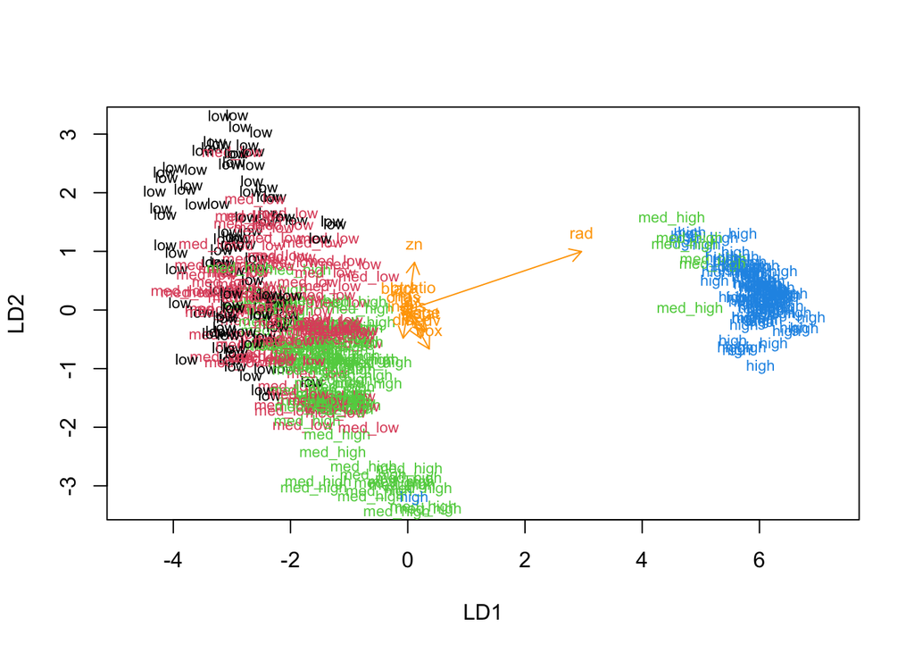

```r
# the function for lda biplot arrows
lda.arrows <- function(x, myscale = 1, arrow_heads = 0.1, color = "orange", tex = 0.75, choices = c(1,2)){
  heads <- coef(x)
  arrows(x0 = 0, y0 = 0,
         x1 = myscale * heads[,choices[1]],
         y1 = myscale * heads[,choices[2]], col=color, length = arrow_heads)
  text(myscale * heads[,choices], labels = row.names(heads),
       cex = tex, col=color, pos=3)
}

# target classes as numeric
classes <- as.numeric(train$crime)

# plot the lda results
plot(lda.fit, dimen = 2, col = classes, pch = classes)
lda.arrows(lda.fit, myscale = 1)
```

It can be observed that **rad** has the most influence over the separation of the model. Moreover, it implies that **rad** variable is more likely to influence the most on the **crim** variable.

### 6. Linear discriminant analysis over test data.

```r
# save the correct classes from test data
correct_classes <- test$crime

# remove the crime variable from test data
test <- dplyr::select(test, -crime)

# predict classes with test data
lda.pred <- predict(lda.fit, newdata = test)

# cross tabulate the results
table(correct = correct_classes, predicted = lda.pred$class)
```

```
##           predicted
## correct    low med_low med_high high
##   low       14       9        0    0
##   med_low    6      14        6    0
##   med_high   0      12       17    0
##   high       0       0        0   24
```

### 7.1 Clustering.

```r
# load MASS and Boston
library(MASS)
data('Boston')

# center and standardize variables
boston_scaled <- scale(Boston)


# change the object to data frame
boston_scaled <- as.data.frame(boston_scaled)


# euclidean distance matrix
dist_eu <- dist(Boston)

# look at the summary of the distances
summary(dist_eu)
```

```
##    Min. 1st Qu.  Median    Mean 3rd Qu.    Max.
##   1.119  85.624 170.539 226.315 371.950 626.047
```

```r
# manhattan distance matrix
dist_man <- dist(Boston, method = 'manhattan')

# look at the summary of the distances
summary(dist_man)
```

```
##     Min.  1st Qu.   Median     Mean  3rd Qu.     Max.
##    2.016  149.145  279.505  342.899  509.707 1198.265
```

### 7.2 K-means clustering

K-means is maybe the most used and known clustering method. It is an unsupervised method, that assigns observations to groups or clusters based on similarity of the objects. In the previous exercise we got a hang of distances. The kmeans() function counts the distance matrix automatically, but it is good to know the basics. Let’s cluster a bit!

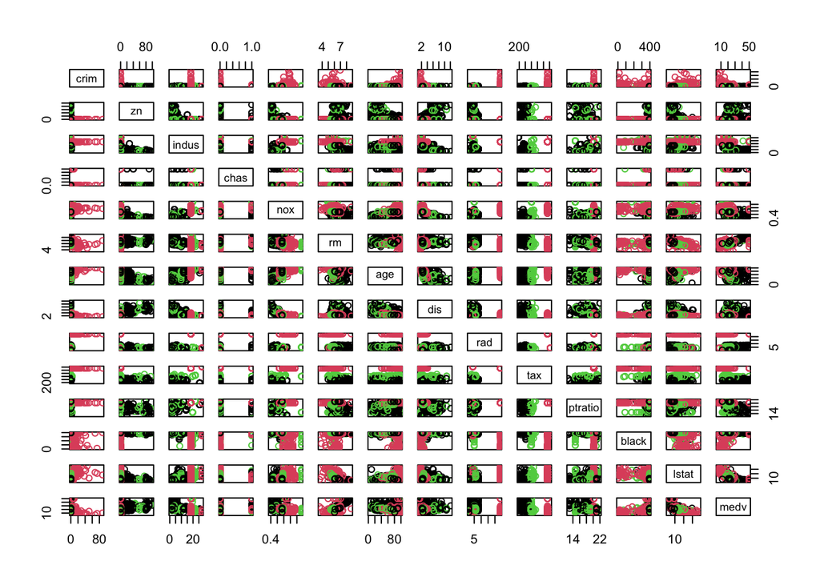

```r
# k-means clustering
km <-kmeans(Boston, centers = 3)

# plot the Boston dataset with clusters
pairs(Boston, col = km$cluster)
```

### 7.3 Investigate the optimal number of clusters

K-means needs the number of clusters as an argument. There are many ways to look at the optimal number of clusters and a good way might depend on the data you have.

One way to determine the number of clusters is to look at how the total of within cluster sum of squares (WCSS) behaves when the number of cluster changes. When you plot the number of clusters and the total WCSS, the optimal number of clusters is when the total WCSS drops radically.

K-means might produce different results every time, because it randomly assigns the initial cluster centers. The function set.seed() can be used to deal with that.

Steps are as follows.

- Set the max number of clusters (k_max) to be 10
- Execute the code to calculate total WCSS. This might take a while.
- Visualize the total WCSS when the number of cluster goes from 1 to 10.

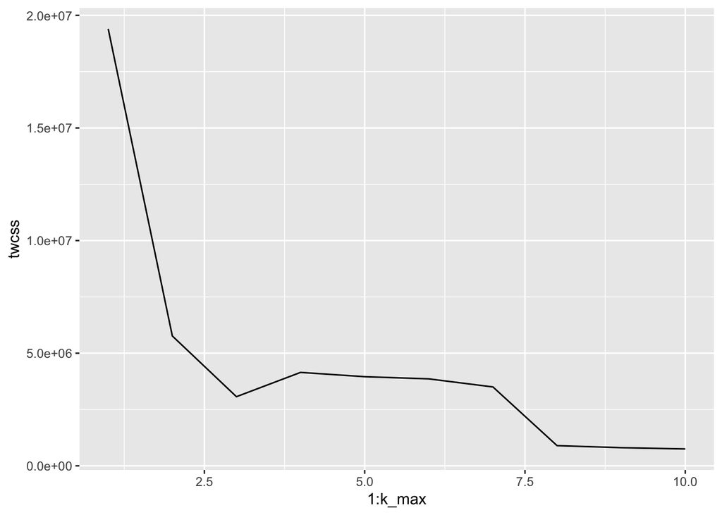

```r
set.seed(123)

# determine the number of clusters
k_max <- 10

# calculate the total within sum of squares
twcss <- sapply(1:k_max, function(k){kmeans(Boston, k)$tot.withinss})

# visualize the results
qplot(x = 1:k_max, y = twcss, geom = 'line')
```

### 7.4 Interpretation of results of total WCSS

The optimal number of clusters is when the value of total WCSS changes radically. In this case, we observe that radical change from 1 to 2. Hence, two clusters would seem optimal.

Next, Run kmeans() again with two clusters and visualize the results.

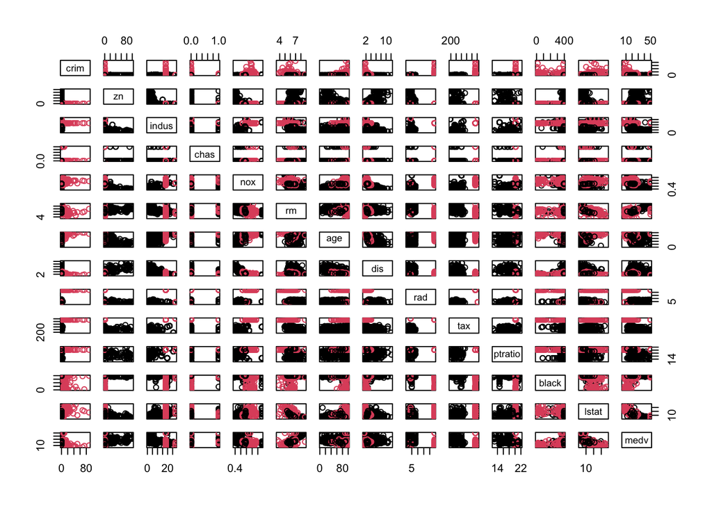

```r
# k-means clustering
km <-kmeans(Boston, centers = 2)

# plot the Boston dataset with clusters
pairs(Boston, col = km$cluster)
```

### Bonus

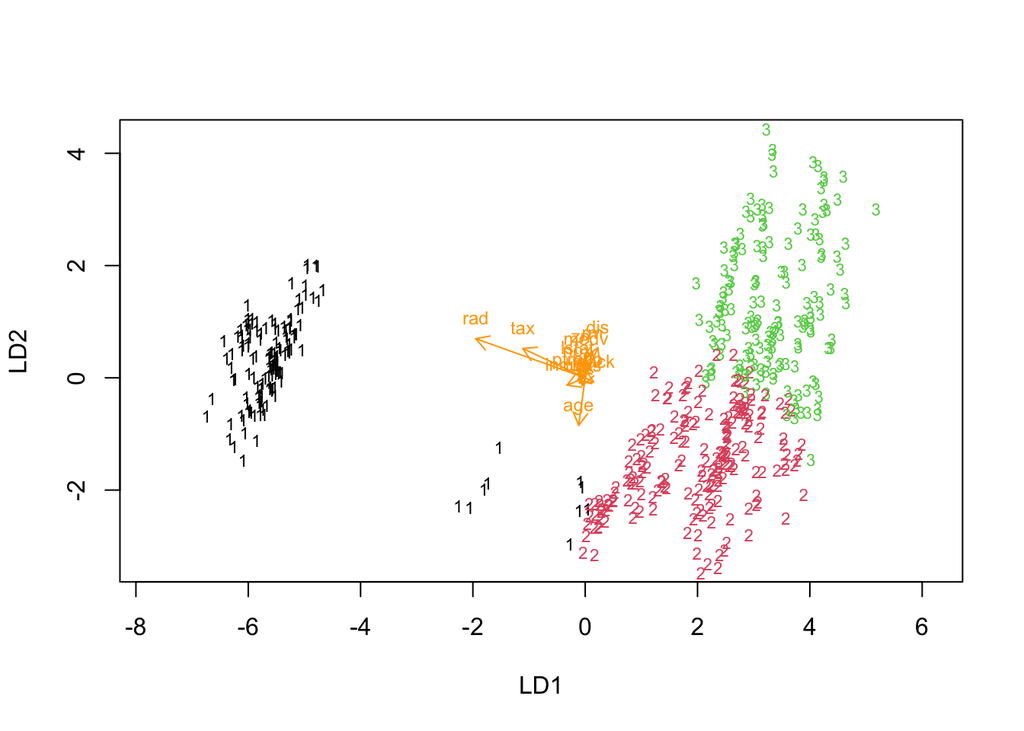

```r
data("Boston")

boston_scaled <- Boston %>%
  scale %>%
  as.data.frame

set.seed(123)
# k-means clustering
km <- kmeans(boston_scaled, centers = 3)

# clusters
boston_b <- boston_scaled %>%
  mutate(crim = as.factor(km$cluster))

# number of rows in the Boston dataset
n <- nrow(boston_b)

# choose randomly 80% of the rows
ind <- sample(n,  size = n * 0.8)

# create train set
train <- boston_b

# create test set
test <- boston_b

correct_classes <- test$crim

test <- dplyr::select(test, -crim)

#  perform LDA using the clusters as target classes
lda.fit <- lda(crim ~ ., data = train)

# target classes as numeric
classes <- as.numeric(train$crim)

# plot the lda results
plot(lda.fit, dimen = 2, col = classes, pch = classes)
lda.arrows(lda.fit, myscale = 1)
```